## Analyzing Product to gauge Positive and Negative Influencing Factors

#### By : Saama Technologies (October, 2016)

### 1: Executive Summary :

In this Analysis, we choose one of the popular DNA Products, with sizable Review Comments. We then extract those reviews through **Web Scraping**, Build the **Local Corpus**, Then apply **Sentiment Analysis** to it and finally derive **Top Influencing Positive & Negative Factors** impacting it. The **Conclusion** Section, at the bottom of this report, lists those factors.

### 2: Selecting the product and Reviews

For this exercise, we selected **Cisco RV110W-A-NA-K9 Small Business RV110W Wireless N VPN Firewall Router** on **Amazon.com**

[figure not shown]

Cisco Router.

Here are some **Review Comments** about this Router,

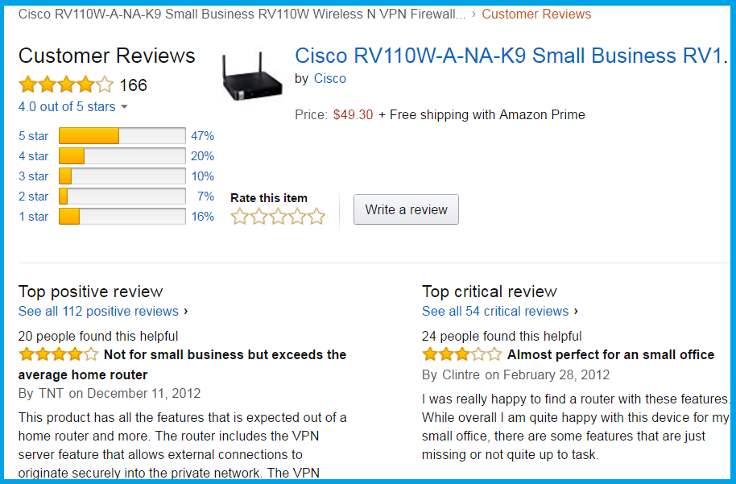

Product Reviews.

### 3: Extracting Reviews

#### 3.1: Web Scraping

Our analysis was entirely done in **R**. One of the most popular, Statistical languages.

After the **Website** and the **Product** was chosen, we wrote R-Code to,

- **Scrape the Website**
- **Extract Relevent Review Comments**
- **Store them As Local Corpus**

#### 3.2: Building the Corpus & Applying Pre-processing

This Corpus needed lot of **Pre-Processing**.

Some of the Pre-processing applied was :

- **Remove URLs**
- **Remove Non-English Letters and Spaces**
- **Convert Text to Lower Case**
- **Stem Words**
- **Remove StopWords**
- **Remove Extra Whitespace**

### 4: Exploratory Data Analysis

Here’s how these **Pre-Processed Review Words** looked like,

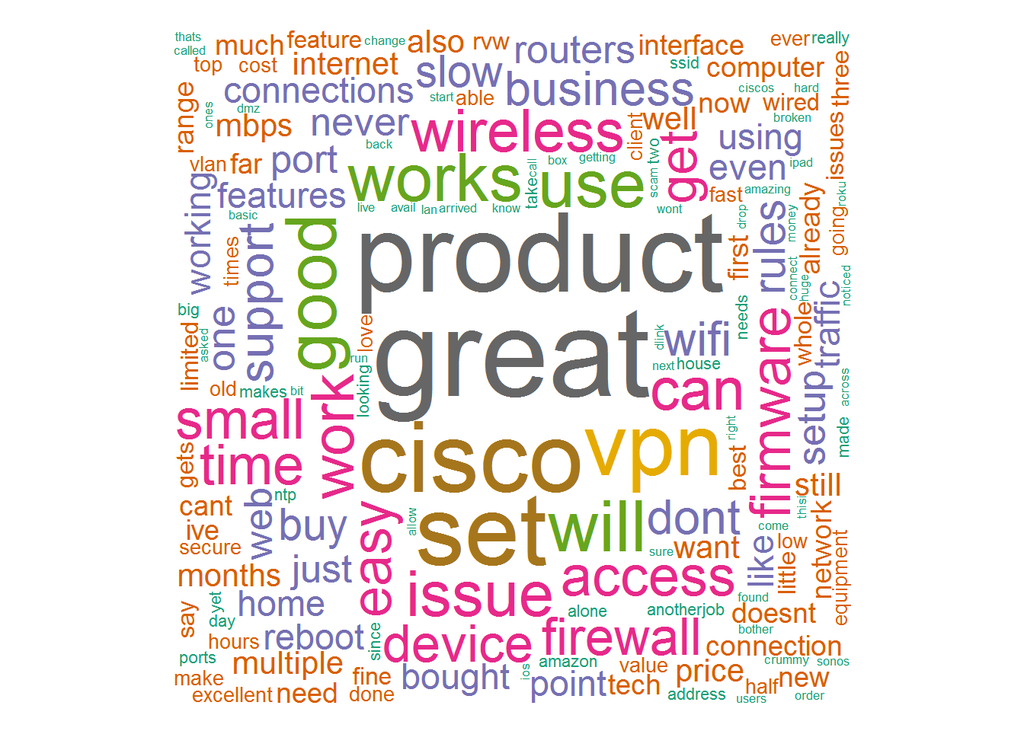

### 5: Performing Sentiment Analysis

#### 5.1: Defined Sentiment Dictionary of Positive and Negative words

Here’s how these **Dictionary Words** looked like,

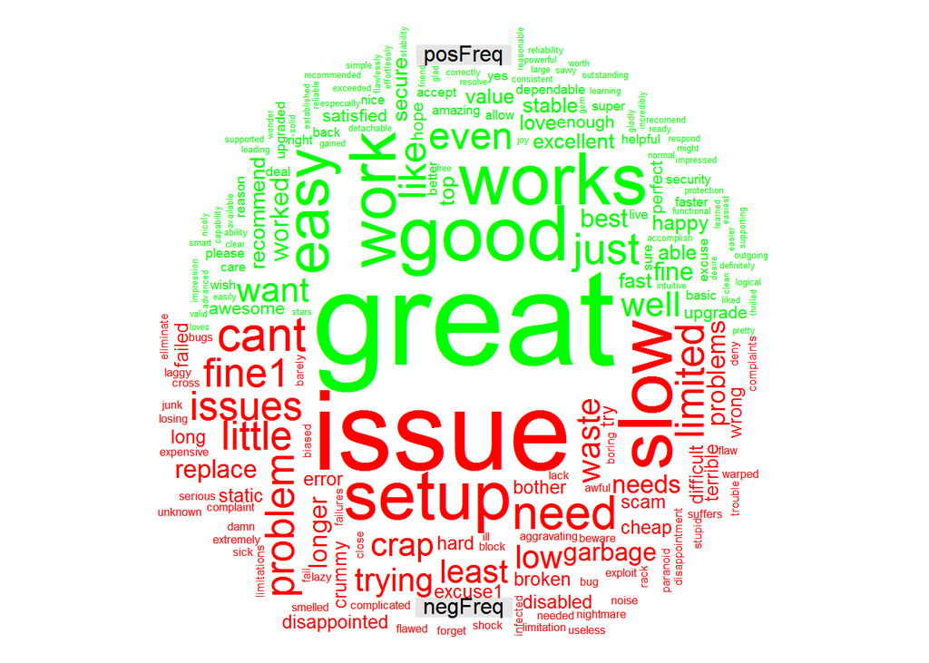

This is how they stacked up,

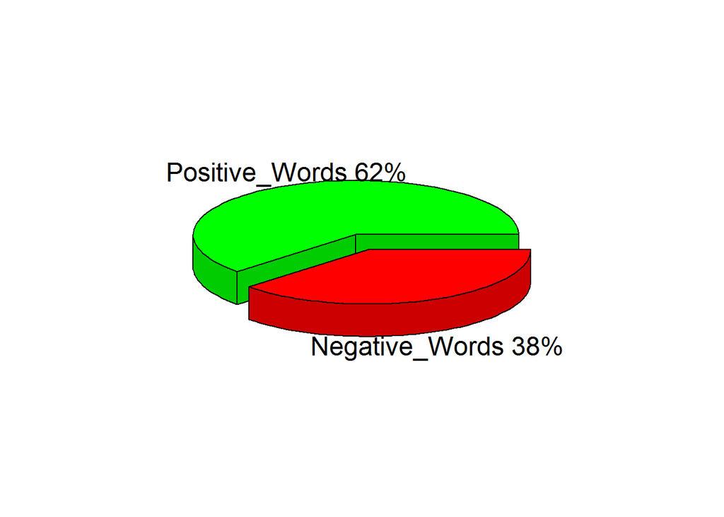

#### 5.2: Tagged each review between 5 Categories

We tagged each Review in one of the following 5 Categories,

- Strongly Positive
- Positive
- Neutral
- Negative
- Strongly Negative

Here are a few examples of **Tagged Reviews**,

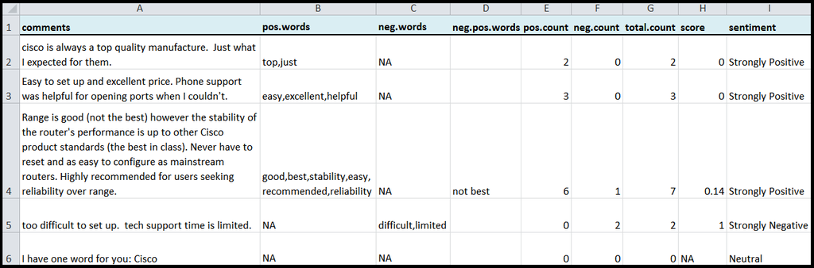

Tagged Reviews.

This is how these **Sentiments** appeared for All Reviews,

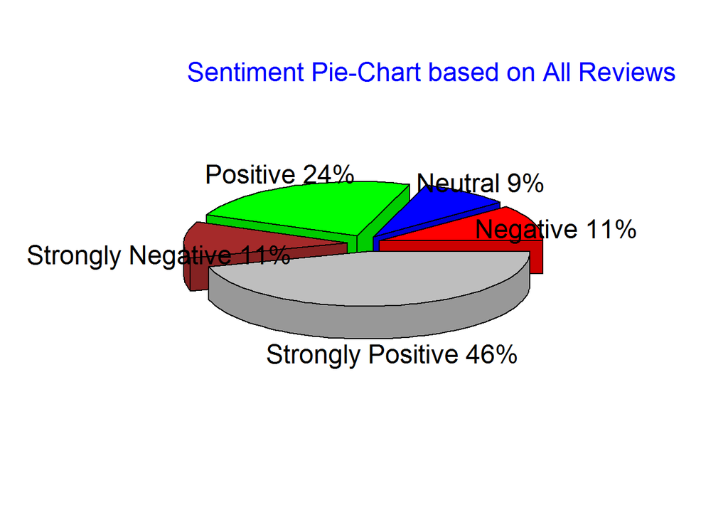

#### 5.3: Identified & Extracted Top Frequency Influencers in each category

We then put each Review in it’s own category. So instead of a Single Corpus, now we had **5 Corpuses**, one for each **Sentiment Category**

Then, for each of these **Corpuses** ie. for each of these **Sentiment Categories**, we found **Top Influencing Factors**

This is how these **Top Influencing Factors** appeared.

Here are **Strongly Positive** Reviews,

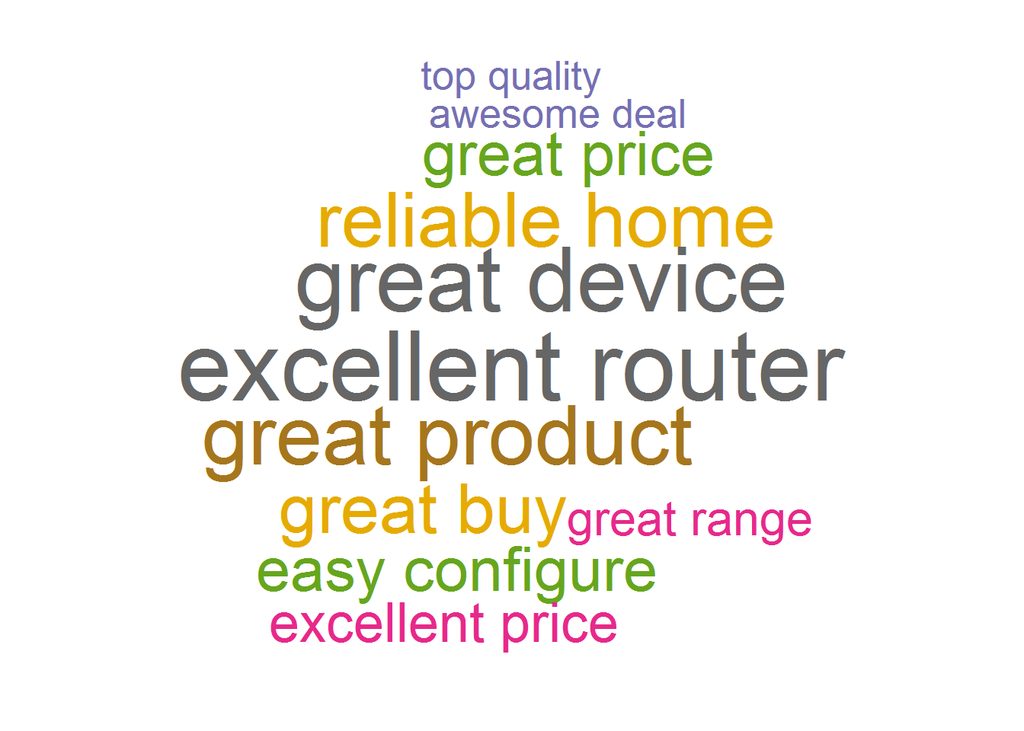

Here are **Positive** Reviews,

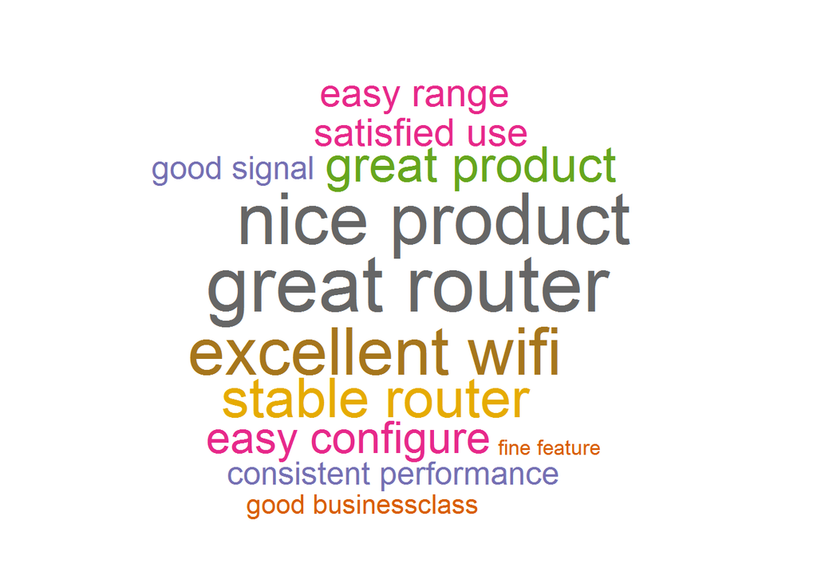

Here are **Negative** Reviews,

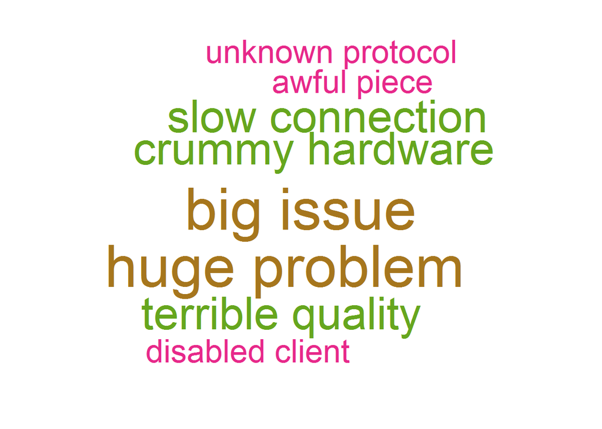

Here are **Strongly Negative** Reviews,

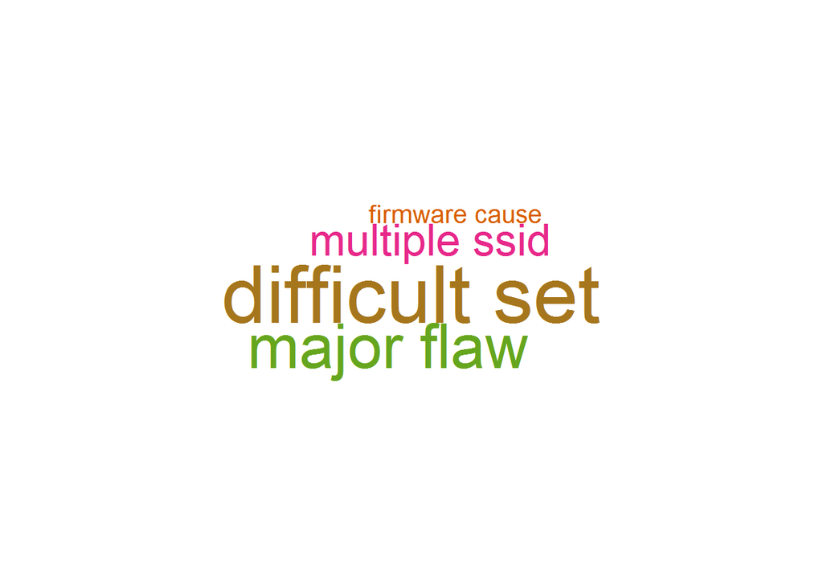

### 6: Conclusion

1. **Strongly Positive** Influencing Factors were : **excellent router, easy configure, great price, awesome deal, top quality, great range**
2. **Positive** Influencing Factors were : **stable router, excellent wifi, good signal**
3. **Negative** Influencing Factors were : **slow connection, crummy hardware, unknown protocol, disabled client**
4. **Strongly Negative** Influencing Factors were : **difficult set, multiple ssid**
5. This analysis was done on a limited data-set of **166 Review Comments**. Detailed Analysis can be performed on **Larger** Review Data-set
6. The **Sentiment Dictionary** was built, based on **Positive** and **Negative** words of **Equal Weightage**. This **Weightage** can be varied to get better results

### 7: Thank You

We thank you for your time and hope that you find this analysis useful. We enjoyed working on it. Looking forward to doing it on a much larger scale.